# Saturated Fat by Diet

Colin Fay

2020-12-06

### 🔎 About the source

Scarborough, P., Appleby, P.N., Mizdrak, A. et al. *Dietary greenhouse gas emissions of meat-eaters, fish-eaters, vegetarians and vegans in the UK*. Climatic Change 125, 179–192 (2014). https://doi.org/10.1007/s10584-014-1169-1

link.springer.com/article/10.1007/s10584-014-1169-1

> Assuming an ordered categorisation (high meat → medium meat → low meat → fish-eaters → vegetarians → vegans), there were significant trends towards lower total fat, saturated fat and protein consumption and higher carbohydrate, total sugar, fibre and fruit and vegetables consumption as animal-based food consumption decreased.

> The diets of 2,041 vegans, 15,751 vegetarians, 8,123 fish-eaters and 29,589 meat-eaters aged 20–79 were assessed using a validated food frequency questionnaire. Comparable GHG emissions parameters were developed for the underlying food codes using a dataset of GHG emissions for 94 food commodities in the UK, with a weighting for the global warming potential of each component gas.

### 📈 Visualising the data

Visualization of *Table 2 Descriptive statistics*.

This visualization displays the mean amount of saturated fat eaten every days for a given diet (either High meat-eaters ( ≥ 100 g/day), Medium meat-eaters (50–99 g/day), Low meat-eaters ( < 50 g/day), Fish-eaters, Vegetarians, or Vegans). Units are expressed in `% energy`.

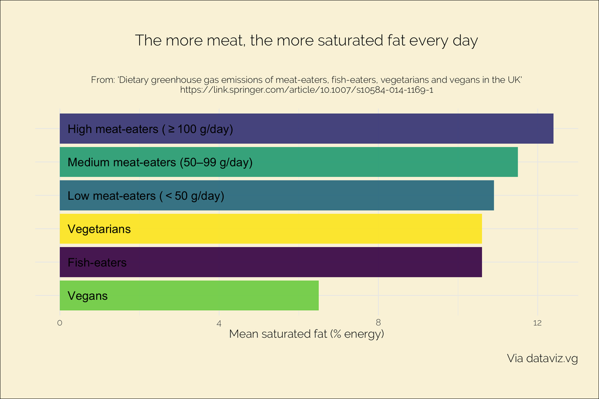

**Show the data**

| Diet | Mean (SD) saturated fat (% energy) |
| --- | --- |
| High meat-eaters ( ≥ 100 g/day) | 12.4 |
| Medium meat-eaters (50–99 g/day) | 11.5 |
| Low meat-eaters ( < 50 g/day) | 10.9 |
| Fish-eaters | 10.6 |
| Vegetarians | 10.6 |
| Vegans | 6.5 |

Code behind this post is available [here](https://github.com/datavizvg/website/blob/main/content/post/2020-12-06-intake.Rmd).